# Online Payments Fraud Detection — Tasks 1–5

# TASK 2 — DATA WRANGLING AND MANIPULATION

## 2.1 Reload clean data + factor target

```r
data <- read.csv("credit_clean.csv") |>
  mutate(
    is_fraud            = factor(is_fraud,            levels = c("legit","fraud")),
    foreign_transaction = factor(foreign_transaction, levels = c("no","yes")),
    location_mismatch   = factor(location_mismatch,   levels = c("no","yes"))
  )
colSums(is.na(data))
```

```
     transaction_id              amount    transaction_hour   merchant_category
                  0                   0                   0                   0
foreign_transaction   location_mismatch  device_trust_score   velocity_last_24h
                  0                   0                   0                   0
     cardholder_age            is_fraud          impossible        micro_amount
                  0                   0                   0                   0
         high_value
                  0
```

## 2.2 Select variables

```r
model_data <- data |>
  select(transaction_id, amount, transaction_hour, merchant_category,
         foreign_transaction, location_mismatch, device_trust_score,
         velocity_last_24h, cardholder_age, is_fraud)
glimpse(model_data)
```

```
Rows: 9,999
Columns: 10
$ transaction_id      <int> 1, 2, 3, 4, 5, 6, 7, 8, 9, 10, 11, 12, 13, 14, 15,…
$ amount              <dbl> 84.47, 541.82, 237.01, 164.33, 30.53, 30.53, 10.77…
$ transaction_hour    <int> 22, 3, 17, 4, 15, 13, 18, 13, 8, 5, 16, 18, 11, 3,…
$ merchant_category   <chr> "Electronics", "Travel", "Grocery", "Grocery", "Fo…
$ foreign_transaction <fct> no, yes, no, no, no, no, no, no, no, no, no, no, n…
$ location_mismatch   <fct> no, no, no, yes, no, no, no, no, no, no, no, no, n…
$ device_trust_score  <int> 66, 87, 49, 72, 79, 90, 48, 68, 80, 59, 58, 30, 73…
$ velocity_last_24h   <int> 3, 1, 1, 3, 0, 2, 1, 1, 0, 1, 2, 4, 4, 2, 2, 2, 1,…
$ cardholder_age      <int> 40, 64, 61, 34, 44, 46, 28, 40, 21, 34, 28, 25, 68…
$ is_fraud            <fct> legit, legit, legit, legit, legit, legit, legit, l…
```

## 2.3 Create new variables

```r
model_data <- model_data |>
  mutate(
    amount_log    = log1p(amount),
    is_night      = transaction_hour %in% 0:5,
    low_trust     = device_trust_score < 40,
    high_velocity = velocity_last_24h >= 5,
    age_group     = cut(cardholder_age, breaks = c(17,29,44,59,100),
                        labels = c("18-29","30-44","45-59","60+"))
  )
```

## 2.4 Filter observations

```r
high_risk       <- model_data |> filter(amount > 500, foreign_transaction == "yes", device_trust_score < 50)
night_fraud     <- model_data |> filter(transaction_hour %in% 0:5, is_fraud == "fraud")
big_electronics <- model_data |> filter(merchant_category == "Electronics", amount > 1000)
suspicious      <- model_data |> filter(is_night | high_velocity | low_trust)

cat("High-risk:",        nrow(high_risk),       "\n")
```

```
High-risk: 21
```

```r
cat("Night fraud:",      nrow(night_fraud),     "\n")
```

```
Night fraud: 124
```

```r
cat("Large Electronics:",nrow(big_electronics), "\n")
```

```
Large Electronics: 11
```

```r
cat("Suspicious:",       nrow(suspicious),      "\n")
```

```
Suspicious: 4212
```

## 2.5 Rename

```r
model_data <- model_data |>
  rename(amount_usd   = amount,
         hour_of_day  = transaction_hour,
         category     = merchant_category,
         trust_score  = device_trust_score,
         velocity_24h = velocity_last_24h,
         age          = cardholder_age)
names(model_data)
```

```
 [1] "transaction_id"      "amount_usd"          "hour_of_day"
 [4] "category"            "foreign_transaction" "location_mismatch"
 [7] "trust_score"         "velocity_24h"        "age"
[10] "is_fraud"            "amount_log"          "is_night"
[13] "low_trust"           "high_velocity"       "age_group"
```

## 2.6 Sort and group

```r
model_data |> arrange(desc(amount_usd)) |>
  select(transaction_id, amount_usd, category, is_fraud) |> head(10)
```

```
   transaction_id amount_usd    category is_fraud
1             532    1471.04 Electronics    legit
2            3650    1390.24    Clothing    legit
3            9928    1370.04     Grocery    legit
4            6124    1354.54 Electronics    legit
5            1465    1339.51     Grocery    legit
6            5789    1321.02 Electronics    legit
7            6759    1285.21 Electronics    legit
8            7456    1227.01    Clothing    legit
9            3403    1225.04 Electronics    legit
10           5324    1209.52    Clothing    legit
```

```r
model_data |> group_by(category) |> tally()
```

```
# A tibble: 5 × 2
  category        n
  <chr>       <int>
1 Clothing     2050
2 Electronics  1923
3 Food         2093
4 Grocery      1944
5 Travel       1989
```

```r
model_data |> group_by(category, is_fraud) |> tally()
```

```
# A tibble: 10 × 3
# Groups:   category [5]
   category    is_fraud     n
   <chr>       <fct>    <int>
 1 Clothing    legit     2026
 2 Clothing    fraud       24
 3 Electronics legit     1899
 4 Electronics fraud       24
 5 Food        legit     2058
 6 Food        fraud       35
 7 Grocery     legit     1905
 8 Grocery     fraud       39
 9 Travel      legit     1960
10 Travel      fraud       29
```

## 2.7 Summary statistics by group

```r
category_summary <- model_data |>
  group_by(category) |>
  summarise(n = n(),
            fraud_n     = sum(is_fraud == "fraud"),
            fraud_rate  = round(fraud_n / n, 4),
            mean_amount = round(mean(amount_usd), 2),
            median_amount = round(median(amount_usd), 2),
            mean_trust  = round(mean(trust_score), 1),
            mean_velocity = round(mean(velocity_24h), 2),
            .groups = "drop") |>
  arrange(desc(fraud_rate))

kable(category_summary,
      caption = "Table 1 - Fraud summary by merchant category",
      col.names = c("Category","Transactions","Fraud Count","Fraud Rate",
                    "Avg Amount","Median Amount","Avg Trust","Avg Velocity"),
      format = "html") |>
  kable_styling(bootstrap_options = c("striped","hover"), full_width = FALSE)
```

Table 1 - Fraud summary by merchant category

| Category | Transactions | Fraud Count | Fraud Rate | Avg Amount | Median Amount | Avg Trust | Avg Velocity |
| --- | --- | --- | --- | --- | --- | --- | --- |
| Grocery | 1944 | 39 | 0.0201 | 176.72 | 123.84 | 61.6 | 2.04 |
| Food | 2093 | 35 | 0.0167 | 173.83 | 119.96 | 61.1 | 2.00 |
| Travel | 1989 | 29 | 0.0146 | 174.87 | 123.75 | 62.3 | 1.97 |
| Electronics | 1923 | 24 | 0.0125 | 178.61 | 119.76 | 62.8 | 1.98 |
| Clothing | 2050 | 24 | 0.0117 | 176.02 | 123.91 | 61.3 | 2.05 |

*** interpretation.** Only 1.5% of transactions are fraudulent. Fraud is spread across **every** merchant category — Grocery highest at ≈2.0%, Clothing lowest at ≈1.2%, a spread of under one percentage point. Mean trust score is ≈62 in all categories, so trust does not separate them. Combined with the EDA finding that numeric predictors are uncorrelated, this says no single variable separates fraud.

# TASK 3 — EXPLORATORY DATA VISUALIZATION

```r
model_data <- read.csv("credit_clean.csv") |>
  mutate(is_fraud = factor(is_fraud, levels = c("legit","fraud")),
         foreign_transaction = factor(foreign_transaction, levels = c("no","yes")),
         location_mismatch   = factor(location_mismatch,   levels = c("no","yes"))) |>
  rename(amount_usd = amount, hour_of_day = transaction_hour,
         category = merchant_category, trust_score = device_trust_score,
         velocity_24h = velocity_last_24h, age = cardholder_age) |>
  mutate(amount_log = log1p(amount_usd),
         is_night   = hour_of_day %in% 0:5)
```

## 3.1 Histogram — amount

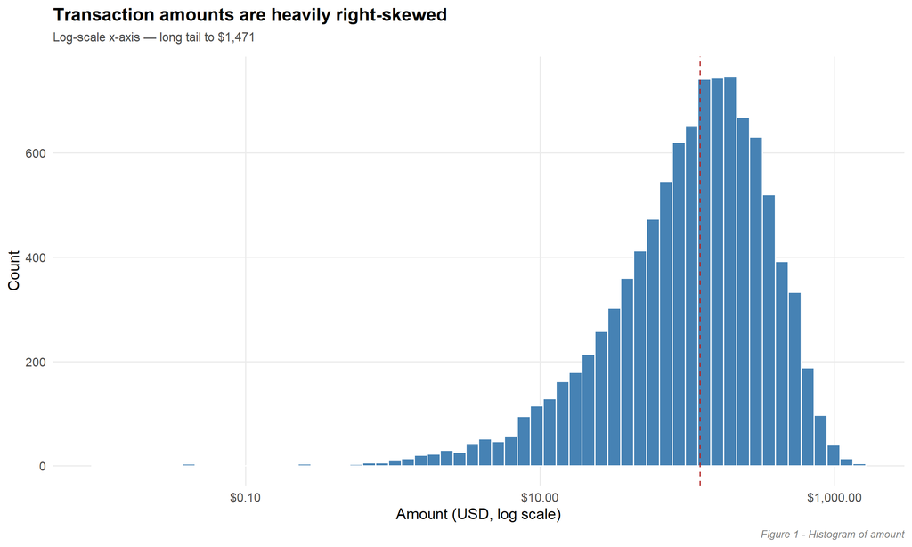

```r
ggplot(model_data, aes(amount_usd)) +
  geom_histogram(bins = 60, fill = "#4682B4", colour = "white") +
  geom_vline(xintercept = median(model_data$amount_usd),
             linetype = "dashed", colour = "#B22222") +
  scale_x_log10(labels = dollar) +
  labs(title = "Transaction amounts are heavily right-skewed",
       subtitle = "Log-scale x-axis — long tail to $1,471",
       x = "Amount (USD, log scale)", y = "Count",
       caption = "Figure 1 - Histogram of amount") + theme_eda()
```

*Why histogram:* best view of a single numeric distribution’s shape. *Reading:* strong right skew; median ≈ $122, mean ≈ $176. *Unusual:* a long tail past $1,000 and a hard floor at $0.01 (micro-charges = card-testing signature).